# Project 1- Cardio Good Fitness- Krithika Srinivasan

```python
import numpy as np
import pandas as pd
import seaborn as sns
import matplotlib.pyplot as plt
```

```python
data = pd.read_csv('C:\\Users\\KXS26XY\\OneDrive - The Home Depot\\Desktop\\Data Science and Business Analytics\\CardioGoodFitness.csv')
data.head()
```

|  | Product | Age | Gender | Education | MaritalStatus | Usage | Fitness | Income | Miles |
| --- | --- | --- | --- | --- | --- | --- | --- | --- | --- |
| 0 | TM195 | 18 | Male | 14 | Single | 3 | 4 | 29562 | 112 |
| 1 | TM195 | 19 | Male | 15 | Single | 2 | 3 | 31836 | 75 |
| 2 | TM195 | 19 | Female | 14 | Partnered | 4 | 3 | 30699 | 66 |
| 3 | TM195 | 19 | Male | 12 | Single | 3 | 3 | 32973 | 85 |
| 4 | TM195 | 20 | Male | 13 | Partnered | 4 | 2 | 35247 | 47 |

```python
data.shape
```

```
(180, 9)
```

```python
data.describe()
```

|  | Age | Education | Usage | Fitness | Income | Miles |
| --- | --- | --- | --- | --- | --- | --- |
| count | 180.000000 | 180.000000 | 180.000000 | 180.000000 | 180.000000 | 180.000000 |
| mean | 28.788889 | 15.572222 | 3.455556 | 3.311111 | 53719.577778 | 103.194444 |
| std | 6.943498 | 1.617055 | 1.084797 | 0.958869 | 16506.684226 | 51.863605 |
| min | 18.000000 | 12.000000 | 2.000000 | 1.000000 | 29562.000000 | 21.000000 |
| 25% | 24.000000 | 14.000000 | 3.000000 | 3.000000 | 44058.750000 | 66.000000 |
| 50% | 26.000000 | 16.000000 | 3.000000 | 3.000000 | 50596.500000 | 94.000000 |
| 75% | 33.000000 | 16.000000 | 4.000000 | 4.000000 | 58668.000000 | 114.750000 |
| max | 50.000000 | 21.000000 | 7.000000 | 5.000000 | 104581.000000 | 360.000000 |

```python
data.isnull().sum()
# No null values in the dataset
```

```
Product          0
Age              0
Gender           0
Education        0
MaritalStatus    0
Usage            0
Fitness          0
Income           0
Miles            0
dtype: int64
```

```python
data['Product'].unique()
# 3 products
```

```
array(['TM195', 'TM498', 'TM798'], dtype=object)
```

3 products

```python
data['Product'].mode()
```

```
0    TM195
dtype: object
```

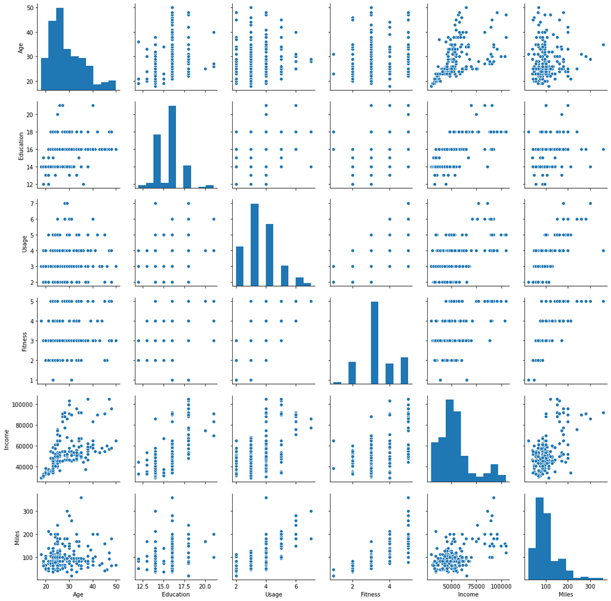

```python
sns.pairplot(data);
```

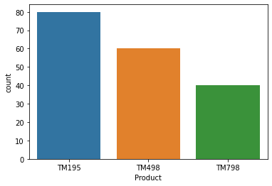

```python
sns.countplot(data['Product']);
# Maximum number of customers for TM195
# Least number of customers for TM798
```

Maximum number of customers for TM195  
Least number of customers for TM798

# Age

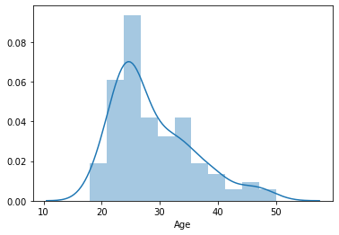

```python
sns.distplot(data['Age']);
```

```python
range = data['Age'].max() - data['Age'].min()
print(range)
# print(data['Age'].max())
# print(data['Age'].min())
```

```
32
```

```python
data['Age'].mean()
data['Age'].median()
data['Age'].mode()

mean = data['Age'].mean()
median = data['Age'].median()
mode = data['Age'].mode()

print('Mean is ', mean)
print('Median is ', median)
print('The two modes are ', mode)
```

```
Mean is  28.788888888888888
Median is  26.0
The two modes are  0    25
dtype: int64
```

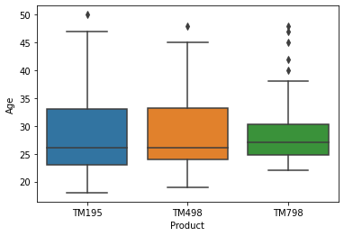

```python
sns.boxplot(data['Product'], data['Age']);
# Median age for TM195 and TM498 is about the same
# Median age for TM798 is a little bit higher than the other two products
```

Median age for TM195 and TM498 is about the same  
Median age for TM798 is a little bit higher than the other two products

```python
data['Age'].groupby(data['Product']).mean()
# Average age for each product is about the same
```

```
Product
TM195    28.55
TM498    28.90
TM798    29.10
Name: Age, dtype: float64
```

```python
data['Age'].groupby(data['Product']).median()
```

```
Product
TM195    26
TM498    26
TM798    27
Name: Age, dtype: int64
```

```python
data['Age'].groupby(data['Product']).quantile(q=0.75)
```

```
Product
TM195    33.00
TM498    33.25
TM798    30.25
Name: Age, dtype: float64
```

```python
data['Age'].groupby(data['Product']).quantile(q=1.00)
```

```
Product
TM195    50.0
TM498    48.0
TM798    48.0
Name: Age, dtype: float64
```

# Gender

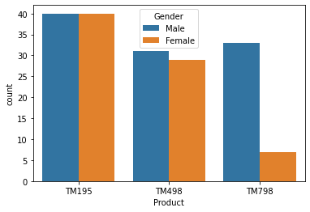

```python
sns.countplot(data['Product'], hue=data['Gender']);
# TM195 is not preferred by one specific gender
# TM498 is preferred a little bit more by males
# TM798 is preferred by males
```

TM195 is not preferred by one specific gender  
TM498 is preferred a little bit more by males  
TM798 is preferred by males

# Education

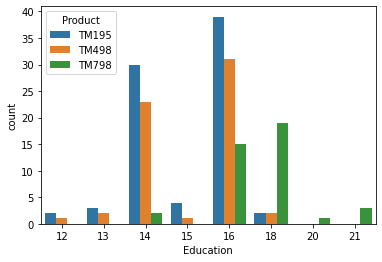

```python
sns.countplot(data['Education'], hue=data['Product']);
```

Maximum number of customers have had 16 years of education

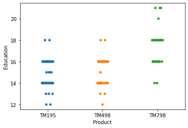

```python
sns.stripplot(data['Product'], data['Education']);
```

```python
range = data['Education'].max() - data['Education'].min()
print(range)
```

```
9
```

```python
data['Education'].mean()
data['Education'].median()
data['Education'].mode()

mean = data['Education'].mean()
median = data['Education'].median()
mode = data['Education'].mode()

print('Mean is ', mean)
print('Median is ', median)
print('The two modes are ', mode)
```

```
Mean is  15.572222222222223
Median is  16.0
The two modes are  0    16
dtype: int64
```

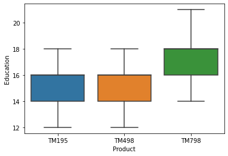

```python
sns.boxplot(data['Product'], data['Education']);
```

Median years of education for TM195 and TM498 is about the same  
Median age for TM798 is higher than the other two products

```python
data['Education'].groupby(data['Product']).mean()
# Average education for each product is about the same
```

```
Product
TM195    15.037500
TM498    15.116667
TM798    17.325000
Name: Education, dtype: float64
```

The average years of education for TM195 and TM498 is lower than the average years of education for TM798

# Marital Status

```python
data['MaritalStatus'].unique()
```

```
array(['Single', 'Partnered'], dtype=object)
```

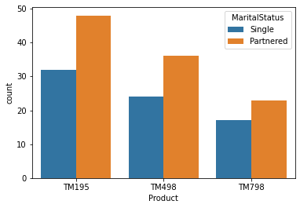

```python
sns.countplot(data['Product'], hue=data['MaritalStatus']);
# All products are preferred by partnered customers
```

All products are preferred by partnered customers

# Usage

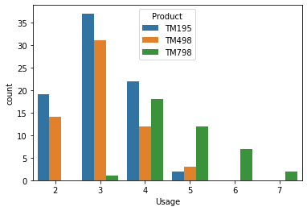

```python
sns.countplot(data['Usage'], hue=data['Product']);
```

Maximum number of customers want to use the treadmills 3 times a week

```python
range = data['Usage'].max() - data['Usage'].min()
print(range)
```

```
5
```

```python
data['Usage'].mean()
data['Usage'].median()
data['Usage'].mode()

mean = data['Usage'].mean()
median = data['Usage'].median()
mode = data['Usage'].mode()

print('Mean is ', mean)
print('Median is ', median)
print('The two modes are ', mode)
```

```
Mean is  3.4555555555555557
Median is  3.0
The two modes are  0    3
dtype: int64
```

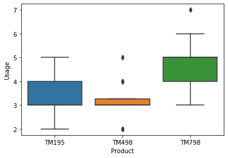

```python
sns.boxplot(data['Product'], data['Usage']);
```

```python
data['Usage'].groupby(data['Product']).mean()
# Average usage for each product is about the same
```

```
Product
TM195    3.087500
TM498    3.066667
TM798    4.775000
Name: Usage, dtype: float64
```

Average usage for TM195 and TM498 is about the same at 3 times per week  
Average usage for TM798 is greater than the other two products

# Fitness

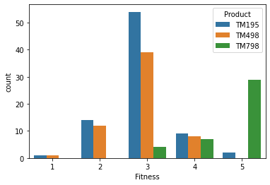

```python
sns.countplot(data['Fitness'], hue=data['Product']);
```

Most customers have rated themselves at 3 in their fitness level  
Product TM798 is mostly bought by those customers who are at a fitness level of 5

```python
range = data['Fitness'].max() - data['Fitness'].min()
print(range)
```

```
4
```

```python
data['Fitness'].mean()
data['Fitness'].median()
data['Fitness'].mode()

mean = data['Fitness'].mean()
median = data['Fitness'].median()
mode = data['Fitness'].mode()

print('Mean is ', mean)
print('Median is ', median)
print('The two modes are ', mode)
```

```
Mean is  3.311111111111111
Median is  3.0
The two modes are  0    3
dtype: int64
```

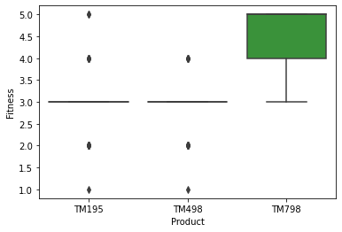

```python
sns.boxplot(data['Product'], data['Fitness']);
```

```python
data['Fitness'].groupby(data['Product']).mean()
```

```
Product
TM195    2.9625
TM498    2.9000
TM798    4.6250
Name: Fitness, dtype: float64
```

Average fitness level of customers who buy TM195 and TM498 is lower than customers who buy TM798

# Income

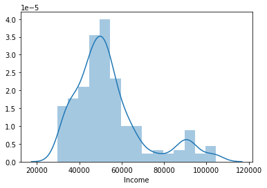

```python
sns.distplot(data['Income']);
```

Most customers fall within the income range of 30000 - 70000

```python
range = data['Income'].max() - data['Income'].min()
print(range)
```

```
75019
```

```python
data['Income'].mean()
data['Income'].median()
data['Income'].mode()

mean = data['Income'].mean()
median = data['Income'].median()
mode = data['Income'].mode()

print('Mean is ', mean)
print('Median is ', median)
print('The two modes are ', mode)
```

```
Mean is  53719.57777777778
Median is  50596.5
The two modes are  0    45480
dtype: int64
```

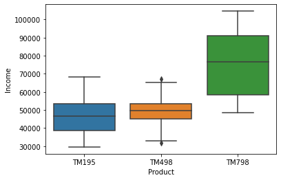

```python
sns.boxplot(data['Product'], data['Income']);
```

Median income of the customers who bought TM798 is much higher compared to the other two products

```python
data['Income'].groupby(data['Product']).mean()
```

```
Product
TM195    46418.025
TM498    48973.650
TM798    75441.575
Name: Income, dtype: float64
```

Average income of customers buying TM798 is higher compared to the other two products

# Miles

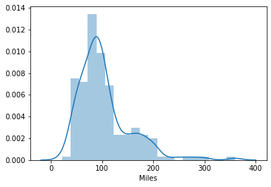

```python
sns.distplot(data['Miles']);
```

Most customers are expected to run in the range of 50-200 miles

```python
range = data['Miles'].max() - data['Miles'].min()
print(range)
```

```
339
```

```python
data['Miles'].mean()
data['Miles'].median()
data['Miles'].mode()

mean = data['Miles'].mean()
median = data['Miles'].median()
mode = data['Miles'].mode()

print('Mean is ', mean)
print('Median is ', median)
print('The two modes are ', mode)
```

```
Mean is  103.19444444444444
Median is  94.0
The two modes are  0    85
dtype: int64
```

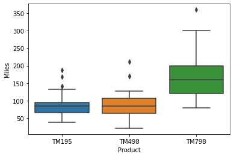

```python
sns.boxplot(data['Product'], data['Miles']);
```

Median expected miles of the customers who bought TM798 is higher compared to the other two products

```python
data['Miles'].groupby(data['Product']).mean()
```

```
Product
TM195     82.787500
TM498     87.933333
TM798    166.900000
Name: Miles, dtype: float64
```

Average expected miles of customers who bought TM798 is almost double of the expected miles of customers who bought the other two products

# Measures of Dispersion

```python
numerical_features = data.select_dtypes(include=['int64', 'float'])
numerical_features.max() - numerical_features.min()
# Range of the different numerical features
```

```
Age             32
Education        9
Usage            5
Fitness          4
Income       75019
Miles          339
dtype: int64
```

```python
data.std()
# Computing the standard deviation of all features
```

```
Age              6.943498
Education        1.617055
Usage            1.084797
Fitness          0.958869
Income       16506.684226
Miles           51.863605
dtype: float64
```

```python
data.var()
# Computing the variance of all features
```

```
Age          4.821217e+01
Education    2.614867e+00
Usage        1.176785e+00
Fitness      9.194289e-01
Income       2.724706e+08
Miles        2.689833e+03
dtype: float64
```

```python
data.mad()
# Computing the mean absolute deviation of all features
```

```
Age              5.615679
Education        1.254568
Usage            0.882963
Fitness          0.765432
Income       11925.873333
Miles           37.208333
dtype: float64
```

# Covariance and Correlation

```python
data.cov()
```

|  | Age | Education | Usage | Fitness | Income | Miles |
| --- | --- | --- | --- | --- | --- | --- |
| Age | 48.212166 | 3.149410 | 0.113470 | 0.406828 | 5.884446e+04 | 13.186530 |
| Education | 3.149410 | 2.614867 | 0.693172 | 0.636623 | 1.670472e+04 | 25.770795 |
| Usage | 0.113470 | 0.693172 | 1.176785 | 0.695469 | 9.303043e+03 | 42.709808 |
| Fitness | 0.406828 | 0.636623 | 0.695469 | 0.919429 | 8.467925e+03 | 39.073246 |
| Income | 58844.463439 | 16704.717815 | 9303.042582 | 8467.925388 | 2.724706e+08 | 465265.361887 |
| Miles | 13.186530 | 25.770795 | 42.709808 | 39.073246 | 4.652654e+05 | 2689.833489 |

Covariance does not give insights into the causation of different features  
We will look at correlation instead

```python
data.corr()
# High correlation between Miles expected to run and Usage
# High correlation between Miles expected to run and Fitness
```

|  | Age | Education | Usage | Fitness | Income | Miles |
| --- | --- | --- | --- | --- | --- | --- |
| Age | 1.000000 | 0.280496 | 0.015064 | 0.061105 | 0.513414 | 0.036618 |
| Education | 0.280496 | 1.000000 | 0.395155 | 0.410581 | 0.625827 | 0.307284 |
| Usage | 0.015064 | 0.395155 | 1.000000 | 0.668606 | 0.519537 | 0.759130 |
| Fitness | 0.061105 | 0.410581 | 0.668606 | 1.000000 | 0.535005 | 0.785702 |
| Income | 0.513414 | 0.625827 | 0.519537 | 0.535005 | 1.000000 | 0.543473 |
| Miles | 0.036618 | 0.307284 | 0.759130 | 0.785702 | 0.543473 | 1.000000 |

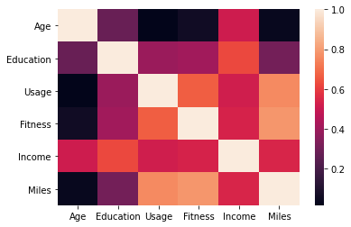

```python
sns.heatmap(data.corr());
```